# soil_tutorial

Nour El-Ajou

2023-11-23

# 1 Data download.

[output not shown]

```r
library(tidyverse)
```

```r
# Load soil data from sampling locations
df_obs <- readr::read_csv(
  here::here("data/berne_soil_sampling_locations.csv")
)
# Display data
head(df_obs) |>
  knitr::kable()
```

| site_id_unique | timeset | x | y | dataset | dclass | waterlog.30 | waterlog.50 | waterlog.100 | ph.0.10 | ph.10.30 | ph.30.50 | ph.50.100 |
| --- | --- | --- | --- | --- | --- | --- | --- | --- | --- | --- | --- | --- |
| 4_26-In-005 | d1968_1974_ptf | 2571994 | 1203001 | validation | poor | 0 | 0 | 1 | 6.071733 | 6.227780 | 7.109235 | 7.214589 |
| 4_26-In-006 | d1974_1978 | 2572149 | 1202965 | calibration | poor | 0 | 1 | 1 | 6.900000 | 6.947128 | 7.203502 | 7.700000 |
| 4_26-In-012 | d1974_1978 | 2572937 | 1203693 | calibration | moderate | 0 | 1 | 1 | 6.200000 | 6.147128 | 5.603502 | 5.904355 |
| 4_26-In-014 | d1974_1978 | 2573374 | 1203710 | validation | well | 0 | 0 | 0 | 6.600000 | 6.754607 | 7.200000 | 7.151129 |
| 4_26-In-015 | d1968_1974_ptf | 2573553 | 1203935 | validation | moderate | 0 | 0 | 1 | 6.272715 | 6.272715 | 6.718392 | 7.269008 |
| 4_26-In-016 | d1968_1974_ptf | 2573310 | 1204328 | calibration | poor | 0 | 0 | 1 | 6.272715 | 6.160700 | 5.559031 | 5.161655 |

# 5.1 Simple Random Forest model

Re-implement the digital soil mapping workflow, using Random Forest, as demonstrated in this tutorial, but for the binary categorical variable waterlog.100. Here are a few hints as a guide:

Make sure that the categorical target variable is encoded as a factor using the function factor().

Start with a model that includes all predictors, trained on the pre-defined training subset.

Evaluate the model on the testing subset of the data

Consider appropriate metrics as described in AGDS Book Chapter 8.3.

Is the data balanced in terms of observed TRUE and FALSE values?

What does this imply for the interpretation of the different metrics?

## Raster files

```r
# Get a list with the path to all raster files
list_raster <- list.files(
  here::here("data/covariates"),
  full.names = TRUE
  )
```

```r
# Display data (lapply to clean names)
lapply(
  list_raster,
  function(x) sub(".*/(.*)", "\\1", x)
  ) |>
  unlist() |>
  head(5) |>
  print()
```

```
## [1] "be_gwn25_hdist.tif" "be_gwn25_vdist.tif" "cindx10_25.tif"
## [4] "cindx50_25.tif"     "geo500h1id.tif"
```

```r
# Load a raster file as example: Picking the slope profile at 2 m resolution
raster_example <- terra::rast(
  here::here("data/covariates/Se_slope2m.tif")
  )
raster_example
```

```
## class       : SpatRaster
## dimensions  : 986, 2428, 1  (nrow, ncol, nlyr)
## resolution  : 20, 20  (x, y)
## extent      : 2568140, 2616700, 1200740, 1220460  (xmin, xmax, ymin, ymax)
## coord. ref. : CH1903+ / LV95
## source      : Se_slope2m.tif
## name        : Se_slope2m
## min value   :    0.00000
## max value   :   85.11286
```

```r
# Load all files as one batch
all_rasters <- terra::rast(list_raster)
all_rasters
```

```
## class       : SpatRaster
## dimensions  : 986, 2428, 91  (nrow, ncol, nlyr)
## resolution  : 20, 20  (x, y)
## extent      : 2568140, 2616700, 1200740, 1220460  (xmin, xmax, ymin, ymax)
## coord. ref. : CH1903+ / LV95
## sources     : be_gwn25_hdist.tif
##               be_gwn25_vdist.tif
##               cindx10_25.tif
##               ... and 88 more source(s)
## names       :  be_gw~hdist, be_gw~vdist, cindx10_25, cindx50_25, geo500h1id, geo500h3id, ...
## min values  :    0.4998779,       0.000,       -100,  -99.99999,          1,          0, ...
## max values  : 3181.2531475,    1165.709,        100,   57.94390,         99,         56, ...
```

## assemble full dataset

```r
# Extract coordinates from sampling locations
sampling_xy <- df_obs |>
  dplyr::select(x, y)

# From all rasters, extract values for sampling coordinates
df_covars <- terra::extract(
  all_rasters,  # The raster we want to extract from
  sampling_xy,  # A matrix of x and y values to extract for
  ID = FALSE    # To not add a default ID column to the output
  )

df_full <- cbind(df_obs, df_covars)

head(df_full) |>
  knitr::kable()
```

| site_id_unique | timeset | x | y | dataset | dclass | waterlog.30 | waterlog.50 | waterlog.100 | ph.0.10 | ph.10.30 | ph.30.50 | ph.50.100 | be_gwn25_hdist | be_gwn25_vdist | cindx10_25 | cindx50_25 | geo500h1id | geo500h3id | lgm | lsf | mrrtf25 | mrvbf25 | mt_gh_y | mt_rr_y | mt_td_y | mt_tt_y | mt_ttvar | NegO | PosO | … |
| --- | --- | --- | --- | --- | --- | --- | --- | --- | --- | --- | --- | --- | --- | --- | --- | --- | --- | --- | --- | --- | --- | --- | --- | --- | --- | --- | --- | --- | --- | --- |
| 4_26-In-005 | d1968_1974_ptf | 2571994 | 1203001 | validation | poor | 0 | 0 | 1 | 6.071733 | 6.227780 | 7.109235 | 7.214589 | 234.39087 | 1.2986320 | -10.62191 | -6.9658718 | 6 | 0 | 7 | 0.0770846 | 0.0184651 | 4.977099 | 1316.922 | 9931.120 | 58 | 98 | 183 | 1.569110 | 1.534734 | … |
| 4_26-In-006 | d1974_1978 | 2572149 | 1202965 | calibration | poor | 0 | 1 | 1 | 6.900000 | 6.947128 | 7.203502 | 7.700000 | 127.41681 | 1.7064546 | -10.87862 | -11.8201790 | 6 | 0 | 7 | 0.0860347 | 0.0544361 | 4.975796 | 1317.000 | 9931.672 | 58 | 98 | 183 | 1.568917 | 1.533827 | … |
| 4_26-In-012 | d1974_1978 | 2572937 | 1203693 | calibration | moderate | 0 | 1 | 1 | 6.200000 | 6.147128 | 5.603502 | 5.904355 | 143.41533 | 0.9372618 | 22.10210 | 0.2093917 | 6 | 0 | 7 | 0.0737963 | 3.6830916 | 4.986864 | 1315.134 | 9935.438 | 58 | 98 | 183 | 1.569093 | 1.543057 | … |
| 4_26-In-014 | d1974_1978 | 2573374 | 1203710 | validation | well | 0 | 0 | 0 | 6.600000 | 6.754607 | 7.200000 | 7.151129 | 165.80418 | 0.7653937 | -20.11569 | -7.7729993 | 6 | 0 | 7 | 0.0859686 | 0.0075817 | 5.285522 | 1315.160 | 9939.923 | 58 | 98 | 183 | 1.569213 | 1.542792 | … |
| 4_26-In-015 | d1968_1974_ptf | 2573553 | 1203935 | validation | moderate | 0 | 0 | 1 | 6.272715 | 6.272715 | 6.718392 | 7.269008 | 61.39244 | 1.0676192 | -55.12566 | -14.0670462 | 6 | 0 | 7 | 0.0650000 | 0.0007469 | 5.894688 | 1315.056 | 9942.032 | 58 | 98 | 183 | 1.570359 | 1.541979 | … |
| 4_26-In-016 | d1968_1974_ptf | 2573310 | 1204328 | calibration | poor | 0 | 0 | 1 | 6.272715 | 6.160700 | 5.559031 | 5.161655 | 310.05014 | 0.1321367 | -17.16055 | -28.0693741 | 6 | 0 | 7 | 0.0731646 | 0.0128017 | 5.938320 | 1315.000 | 9940.597 | 58 | 98 | 183 | 1.569434 | 1.541606 | … |

## Facotor encoding for few-level variables

```r
vars_categorical <- df_covars |>

  # Get number of distinct values per variable
  dplyr::summarise(dplyr::across(dplyr::everything(), ~dplyr::n_distinct(.))) |>

  # Turn df into long format for easy filtering
  tidyr::pivot_longer(
    dplyr::everything(),
    names_to = "variable",
    values_to = "n"
    ) |>

  # Filter out variables with 10 or less distinct values
  dplyr::filter(n <= 10) |>

  # Extract the names of these variables
  dplyr::pull('variable')

cat("Variables with less than 10 distinct values:",
    ifelse(length(vars_categorical) == 0, "none", vars_categorical))
```

```
## Variables with less than 10 distinct values: geo500h1id
```

```r
df_full <- df_full |>
  dplyr::mutate(dplyr::across(all_of(vars_categorical), ~as.factor(.)))
```

## missing values

```r
# Get number of rows to calculate percentages
n_rows <- nrow(df_full)

# Get number of distinct values per variable
df_full |>
  dplyr::summarise(dplyr::across(dplyr::everything(),
                                 ~ length(.) - sum(is.na(.)))) |>
  tidyr::pivot_longer(dplyr::everything(),
                      names_to = "variable",
                      values_to = "n") |>
  dplyr::mutate(perc_available = round(n / n_rows * 100)) |>
  dplyr::arrange(perc_available) |>
  head(10) |>
  knitr::kable()
```

| variable | n | perc_available |
| --- | --- | --- |
| ph.30.50 | 856 | 81 |
| ph.10.30 | 866 | 82 |
| ph.50.100 | 859 | 82 |
| timeset | 871 | 83 |
| ph.0.10 | 870 | 83 |
| dclass | 1006 | 96 |
| site_id_unique | 1052 | 100 |
| x | 1052 | 100 |
| y | 1052 | 100 |
| dataset | 1052 | 100 |

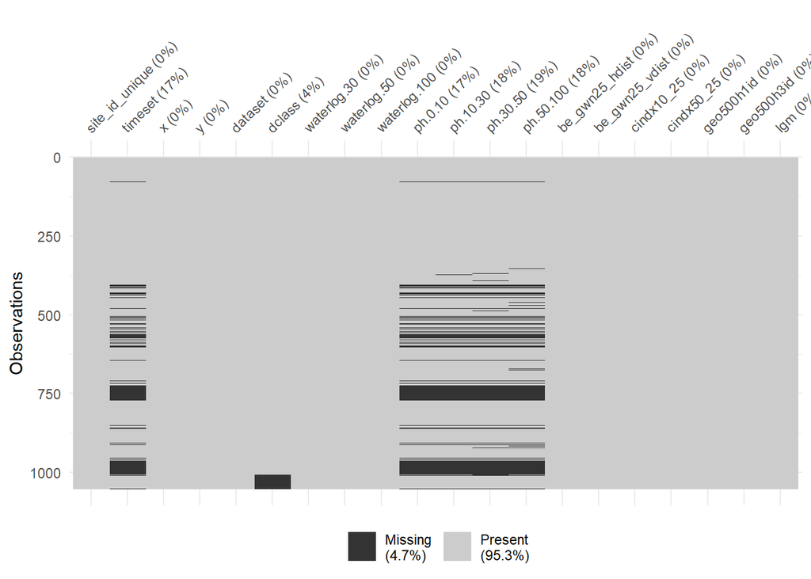

```r
df_full |>
  dplyr::select(1:20) |>   # reduce data for readability of the plot
  visdat::vis_miss()
```

We see that our target variable “waterlog.100”, doesn’t have any missing values.

```r
# if (!dir.exists(here::here("data"))) system(paste0("mkdir ", here::here("data")))
# saveRDS(df_full,
        # here::here("data/df_full.rds"))
```

## Train a random forest

## Definition of Targets and Predictors

```r
df_full <- readRDS(here::here("data/df_full.rds"))

head(df_full) |>
  knitr::kable()
```

| site_id_unique | timeset | x | y | dataset | dclass | waterlog.30 | waterlog.50 | waterlog.100 | ph.0.10 | ph.10.30 | ph.30.50 | ph.50.100 | be_gwn25_hdist | be_gwn25_vdist | cindx10_25 | cindx50_25 | geo500h1id | geo500h3id | lgm | lsf | mrrtf25 | mrvbf25 | mt_gh_y | mt_rr_y | mt_td_y | mt_tt_y | mt_ttvar | NegO | PosO | … |
| --- | --- | --- | --- | --- | --- | --- | --- | --- | --- | --- | --- | --- | --- | --- | --- | --- | --- | --- | --- | --- | --- | --- | --- | --- | --- | --- | --- | --- | --- | --- |
| 4_26-In-005 | d1968_1974_ptf | 2571994 | 1203001 | validation | poor | 0 | 0 | 1 | 6.071733 | 6.227780 | 7.109235 | 7.214589 | 234.39087 | 1.2986320 | -10.62191 | -6.9658718 | 6 | 0 | 7 | 0.0770846 | 0.0184651 | 4.977099 | 1316.922 | 9931.120 | 58 | 98 | 183 | 1.569110 | 1.534734 | … |
| 4_26-In-006 | d1974_1978 | 2572149 | 1202965 | calibration | poor | 0 | 1 | 1 | 6.900000 | 6.947128 | 7.203502 | 7.700000 | 127.41681 | 1.7064546 | -10.87862 | -11.8201790 | 6 | 0 | 7 | 0.0860347 | 0.0544361 | 4.975796 | 1317.000 | 9931.672 | 58 | 98 | 183 | 1.568917 | 1.533827 | … |
| 4_26-In-012 | d1974_1978 | 2572937 | 1203693 | calibration | moderate | 0 | 1 | 1 | 6.200000 | 6.147128 | 5.603502 | 5.904355 | 143.41533 | 0.9372618 | 22.10210 | 0.2093917 | 6 | 0 | 7 | 0.0737963 | 3.6830916 | 4.986864 | 1315.134 | 9935.438 | 58 | 98 | 183 | 1.569093 | 1.543057 | … |
| 4_26-In-014 | d1974_1978 | 2573374 | 1203710 | validation | well | 0 | 0 | 0 | 6.600000 | 6.754607 | 7.200000 | 7.151129 | 165.80418 | 0.7653937 | -20.11569 | -7.7729993 | 6 | 0 | 7 | 0.0859686 | 0.0075817 | 5.285522 | 1315.160 | 9939.923 | 58 | 98 | 183 | 1.569213 | 1.542792 | … |
| 4_26-In-015 | d1968_1974_ptf | 2573553 | 1203935 | validation | moderate | 0 | 0 | 1 | 6.272715 | 6.272715 | 6.718392 | 7.269008 | 61.39244 | 1.0676192 | -55.12566 | -14.0670462 | 6 | 0 | 7 | 0.0650000 | 0.0007469 | 5.894688 | 1315.056 | 9942.032 | 58 | 98 | 183 | 1.570359 | 1.541979 | … |
| 4_26-In-016 | d1968_1974_ptf | 2573310 | 1204328 | calibration | poor | 0 | 0 | 1 | 6.272715 | 6.160700 | 5.559031 | 5.161655 | 310.05014 | 0.1321367 | -17.16055 | -28.0693741 | 6 | 0 | 7 | 0.0731646 | 0.0128017 | 5.938320 | 1315.000 | 9940.597 | 58 | 98 | 183 | 1.569434 | 1.541606 | … |

```r
# Specify target: The pH in the top 10cm
target <- "waterlog.100"
df_full <- subset(df_full, select = - c(vszone) )

# Specify predictors_all: Remove soil sampling and observational data
predictors_all <- names(df_full)[14:ncol(df_full)]


cat("The target is:", target,
    "\nThe predictors_all are:", paste0(predictors_all[1:8], sep = ", "), "...")
```

```
## The target is: waterlog.100
## The predictors_all are: be_gwn25_hdist,  be_gwn25_vdist,  cindx10_25,  cindx50_25,  geo500h1id,  geo500h3id,  lgm,  lsf,  ...
```

## Training and Test Dataset

```r
df_full$waterlog.100 <- as.factor(df_full$waterlog.100)

# Split dataset into training and testing sets
df_train <- df_full |> dplyr::filter(dataset == "calibration")
df_test  <- df_full |> dplyr::filter(dataset == "validation")

# Filter out any NA to avoid error when running a Random Forest
df_train <- df_train |> tidyr::drop_na()
df_test <- df_test   |> tidyr::drop_na()

# A little bit of verbose output:
n_tot <- nrow(df_train) + nrow(df_test)

perc_cal <- (nrow(df_train) / n_tot) |> round(2) * 100
perc_val <- (nrow(df_test)  / n_tot) |> round(2) * 100

cat("For model training, we have a calibration / validation split of: ",
    perc_cal, "/", perc_val, "%")
```

```
## For model training, we have a calibration / validation split of:  75 / 25 %
```

## Train basic forest

```r
# ranger() crashes when using tibbles, so we are using the
# base R notation to enter the data
rf_basic <- ranger::ranger(
  y = df_train[, target],     # target variable
  x = df_train[, predictors_all], # Predictor variables
  seed = 42,                    # Specify the seed for randomization to reproduce the same model again
  num.threads = parallel::detectCores() - 1) # Use all but one CPU core for quick model training

# Print a summary of fitted model
print(rf_basic)
```

```
## Ranger result
##
## Call:
##  ranger::ranger(y = df_train[, target], x = df_train[, predictors_all],      seed = 42, num.threads = parallel::detectCores() - 1)
##
## Type:                             Classification
## Number of trees:                  500
## Sample size:                      605
## Number of independent variables:  90
## Mtry:                             9
## Target node size:                 1
## Variable importance mode:         none
## Splitrule:                        gini
## OOB prediction error:             21.16 %
```

```r
# Load area to be predicted
raster_mask <- terra::rast(here::here("data/area_to_be_mapped.tif"))


# Turn target raster into a dataframe, 1 px = 1 cell
df_mask <- as.data.frame(raster_mask, xy = TRUE)

# Filter only for area of interest
df_mask <- df_mask |>
  dplyr::filter(area_to_be_mapped == 1)

# Display df
head(df_mask) |>
  knitr::kable()
```

| x | y | area_to_be_mapped |
| --- | --- | --- |
| 2587670 | 1219750 | 1 |
| 2587690 | 1219750 | 1 |
| 2587090 | 1219190 | 1 |
| 2587090 | 1219170 | 1 |
| 2587110 | 1219170 | 1 |
| 2587070 | 1219150 | 1 |

```r
files_covariates <- list.files(
  path = here::here("data/covariates/"),
  pattern = ".tif$",
  recursive = TRUE,
  full.names = TRUE
  )
```

```r
 random_files <- sample(files_covariates, 2)
terra::rast(random_files[1])
```

```
## class       : SpatRaster
## dimensions  : 986, 2428, 1  (nrow, ncol, nlyr)
## resolution  : 20, 20  (x, y)
## extent      : 2568140, 2616700, 1200740, 1220460  (xmin, xmax, ymin, ymax)
## coord. ref. : CH1903+ / LV95
## source      : Se_alti2m_std_50c.tif
## name        : Se_alti2m_std_50c
## min value   :           0.00000
## max value   :          59.55298
```

## Select Raster and covariates - basic Forest

```r
# Filter that list only for the variables used in the RF
preds_selected <- names(df_train[ ,predictors_all])
files_selected <- files_covariates[apply(sapply(X = preds_selected,
                                            FUN = grepl,
                                            files_covariates),
                                     MARGIN =  1,
                                     FUN = any)]

# Load all rasters as a stack
raster_covariates <- terra::rast(files_selected)
```

## Get coordinates for covariates - Basic Forest

```r
# Get coordinates for which we want data
df_locations <- df_mask |>
  dplyr::select(x, y)

# Extract data from covariate raster stack for all gridcells in the raster
df_predict <- terra::extract(
  raster_covariates,   # The raster we want to extract from
  df_locations,        # A matrix of x and y values to extract for
  ID = FALSE           # To not add a default ID column to the output
  )

df_predict <- cbind(df_locations, df_predict) |>
  tidyr::drop_na()  # Se_TWI2m has a small number of missing data
```

## Generate prediction and add it to test-set - Basic Forest

```r
# Need to load {ranger} because ranger-object is used in predict()
library(ranger)
# Make predictions for validation sites
prediction <- predict(
  rf_basic,           # RF model
  data = df_test,   # Predictor data
  num.threads = parallel::detectCores() - 1
  )

# Save predictions to validation df
df_test$pred <- prediction$predictions
```

## predictions with Prediction set - Basic Forest

```r
# Make predictions using the RF model
prediction <- predict(
  rf_basic,              # RF model
  data = df_predict,
  num.threads = parallel::detectCores() - 1
  )


# Attach predictions to dataframe and round them
df_predict$prediction <- prediction$predictions
```

## Extract data frame and raster transformation - Basic Forest

```r
# Extract dataframe with coordinates and predictions
df_map <- df_predict |>
  dplyr::select(x, y, prediction)

# Turn dataframe into a raster
raster_pred <- terra::rast(
  df_map,                  # Table to be transformed
  crs = "+init=epsg:2056", # Swiss coordinate system
  extent = terra::ext(raster_covariates) # Prescribe same extent as predictor rasters
  )
```

## Plot Prediction map - Basic Forest

```
## SpatRaster resampled to ncells = 500610
```

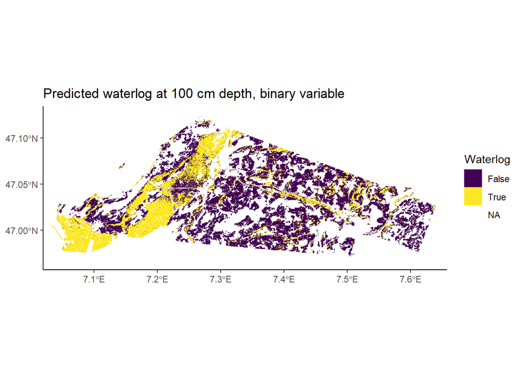

```r
raster_pred_plot <- terra::as.factor(raster_pred)
raster_pred_plot_df <- terra::as.data.frame(raster_pred_plot)

# Let's have a look at our predictions!
# To have some more flexibility, we can plot this in the ggplot-style as such:
ggplot2::ggplot(raster_pred_plot_df) +
  tidyterra::geom_spatraster(data = raster_pred_plot) +
  ggplot2::scale_fill_viridis_d(
    na.value = NA,
    option = "viridis",
    name = "Waterlog",
    labels = c("False", "True")
    ) +
  ggplot2::theme_classic() +
  ggplot2::scale_x_continuous(expand = c(0, 0)) +
  ggplot2::scale_y_continuous(expand = c(0, 0)) +
  ggplot2::labs(title = "Predicted waterlog at 100 cm depth, binary variable")
```

```r
# Save raster as .tif file
terra::writeRaster(
  raster_pred,
  "../data/ra_predicted_ph0-10.tif",
  datatype = "FLT4S",  # FLT4S for floats, INT1U for integers (smaller file)
  filetype = "GTiff",  # GeoTiff format
  overwrite = TRUE     # Overwrite existing file
)
```

## Balance of dataset and implications

Evaluate the model on the testing subset of the data. Consider appropriate metrics as described in AGDS Book Chapter 8.3. Is the data balanced in terms of observed TRUE and FALSE values? What does this imply for the interpretation of the different metrics?

Answer:

The balance considers our target variable in this case “Water.log.100”, which is binary (0,1) encoded. We are interested to check if we have roughly as many ones as zeros in our data set, which would be desirable.

The reason for this is that if, for example we would have mostly zeros, a simple algorithm (like one ignoring all covariates ) would always return a zero for new predictions. Consequently in this scenario, an unbalanced dataset would result in a high share of false negatives (since all predictions would be zeros). Accordingly, an unbalanced dataset in the other direction, containing mostly ones, would result in a high share of false positives which is also not desirable. This is why we want our target variable to be balanced.

### check for balance

Since we estimate our model only with the trainings set, this dataframe ist the important one in order to check for the balance.

```r
summary(df_train$waterlog.100 == 1)
```

```
##    Mode   FALSE    TRUE
## logical     358     247
```

```r
share_of_postives_train <-  as.numeric(summary(df_train$waterlog.100 == 1)[3])/  ( (as.numeric(summary(df_train$waterlog.100 == 1)[2]) ) +
   (as.numeric(summary(df_train$waterlog.100 == 1)[3]) ) )

cat("the percentage of positives is equal to ", share_of_postives_train, "in the training dataset")
```

```
## the percentage of positives is equal to  0.4082645 in the training dataset
```

Consequently there is a reasonable chance to get an unrepresentative high number of false negatives in our predictions, which is relevant for the confusion matrices and the resulting diagnostic estimators. Namely the accurace = (TP + TN)/N could be underestimated by our models.

#confusion matrix - basic case

```r
# Make classification predictions
y <- as.factor(df_test$waterlog.100)
x <- df_test$pred # Use 0.5 as threshold

# Change class names
levels(y) <- levels(x) <- c("no", "yes")

# plot confusion matrix
conf_matrix_basic <- caret::confusionMatrix(data = x, reference = y)
conf_matrix_basic
```

```
## Confusion Matrix and Statistics
##
##           Reference
## Prediction  no yes
##        no  105  23
##        yes  25  47
##
##                Accuracy : 0.76
##                  95% CI : (0.6947, 0.8174)
##     No Information Rate : 0.65
##     P-Value [Acc > NIR] : 0.0005292
##
##                   Kappa : 0.476
##
##  Mcnemar's Test P-Value : 0.8852339
##
##             Sensitivity : 0.8077
##             Specificity : 0.6714
##          Pos Pred Value : 0.8203
##          Neg Pred Value : 0.6528
##              Prevalence : 0.6500
##          Detection Rate : 0.5250
##    Detection Prevalence : 0.6400
##       Balanced Accuracy : 0.7396
##
##        'Positive' Class : no
##
```

Consider appropriate metrics as described in AGDS Book Chapter 8.3. Is the data balanced in terms of observed TRUE and FALSE values?

```r
tp_basic <- conf_matrix_basic$table[2,2]
fp_basic <- conf_matrix_basic$table[2,1]

tn_basic <- conf_matrix_basic$table[1,1]
fn_basic <- conf_matrix_basic$table[1,2]
```

Accuracy = (TP + TN )/ N

```r
acc_basic <- na.omit( (tp_basic + tn_basic )/ sum(conf_matrix_basic$table) )
cat("the accuracy for the basic model is ",acc_basic)
```

```
## the accuracy for the basic model is  0.76
```

Precision = TP / (TP + FP)

```r
prec_basic <- na.omit(tp_basic / (tp_basic + fp_basic) )
cat("the precision for the basic model is ",prec_basic)
```

```
## the precision for the basic model is  0.6527778
```

f1 <- 2TP / (2TP + FP + FN)

```r
f1_basic <-  na.omit(2*tp_basic / (2*tp_basic + fp_basic +fn_basic) )
cat("the f1 for the basic model is ",f1_basic)
```

```
## the f1 for the basic model is  0.6619718
```

# 5.2 Variable selection (Boruta)

## 5.2.1

Reduce the predictor set as demonstrated in this tutorial.

### Variable importance basic model

```r
# Let's run the basic model again but with recording the variable importance
rf_basic <- ranger::ranger(
  y = df_train[, target],     # target variable
  x = df_train[, predictors_all],   # Predictor variables
  importance   = "permutation", # Pick permutation to calculate variable importance
  seed = 42,                    # Specify seed for randomization to reproduce the same model again
  num.threads = parallel::detectCores() - 1) # Use all but one CPU core for quick model training

# Extract the variable importance and create a long tibble
vi_rf_basic <- rf_basic$variable.importance |>
  dplyr::bind_rows() |>
  tidyr::pivot_longer(cols = dplyr::everything(), names_to = "variable")

# Plot variable importance, ordered by decreasing value
gg <- vi_rf_basic |>
  ggplot2::ggplot(ggplot2::aes(x = reorder(variable, value), y = value)) +
  ggplot2::geom_bar(stat = "identity", fill = "grey50", width = 0.75) +
  ggplot2::labs(
    y = "Change in OOB MSE after permutation",
    x = "",
    title = "Variable importance based on OOB") +
  ggplot2::theme_classic() +
  ggplot2::coord_flip() + ggplot2::theme(axis.text.y = ggplot2::element_text(angle = 45, hjust = 1) )

vi_rf_basic
```

```
## # A tibble: 90 × 2
##    variable            value
##    <chr>               <dbl>
##  1 be_gwn25_hdist  0.00240
##  2 be_gwn25_vdist  0.0138
##  3 cindx10_25      0.00579
##  4 cindx50_25      0.00194
##  5 geo500h1id      0.00115
##  6 geo500h3id      0.0000367
##  7 lgm            -0.0000428
##  8 lsf             0.00879
##  9 mrrtf25         0.00158
## 10 mrvbf25         0.0168
## # ℹ 80 more rows
```

```r
# Display plot
# gg
```

## 5.2.2 Run Boruta Algorithm

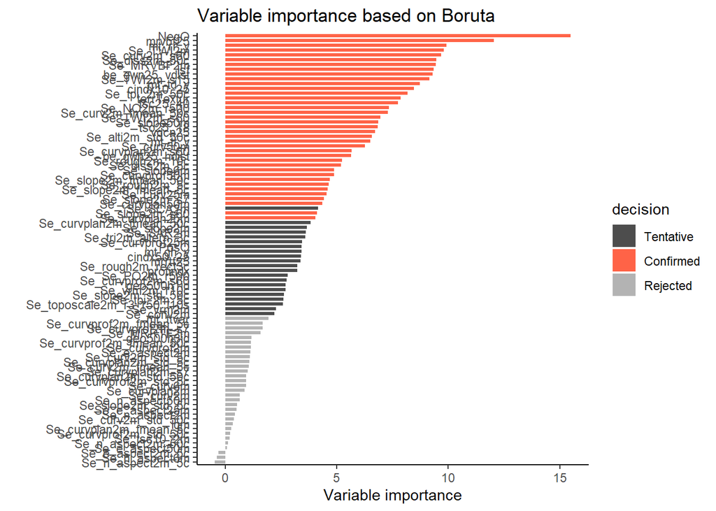

```r
set.seed(42)

# run the algorithm
bor <- Boruta::Boruta(
    y = df_train[, target],
    x = df_train[, predictors_all],
    maxRuns = 50, # Number of iterations. Set to 30 or lower if it takes too long
    num.threads = parallel::detectCores()-1)

# obtain results: a data frame with all variables, ordered by their importance
df_bor <- Boruta::attStats(bor) |>
  tibble::rownames_to_column() |>
  dplyr::arrange(dplyr::desc(meanImp))

# plot the importance result
ggplot2::ggplot(ggplot2::aes(x = reorder(rowname, meanImp),
                             y = meanImp,
                             fill = decision),
                data = df_bor) +
  ggplot2::geom_bar(stat = "identity", width = 0.75) +
  ggplot2::scale_fill_manual(values = c("grey30", "tomato", "grey70")) +
  ggplot2::labs(
    y = "Variable importance",
    x = "",
    title = "Variable importance based on Boruta") +
  ggplot2::theme_classic() +
  ggplot2::coord_flip()
```

## retrain RF with Boruta Selection

```r
# get retained important variables
predictors_selected <- df_bor |>
  dplyr::filter(decision == "Confirmed") |>
  dplyr::pull(rowname)

length(predictors_selected)
```

```
## [1] 38
```

```r
# re-train Random Forest model
rf_bor <- ranger::ranger(
  y = df_train[, target],              # target variable
  x = df_train[, predictors_selected], # Predictor variables
  seed = 42,                           # Specify the seed for randomization to reproduce the same model again
  num.threads = parallel::detectCores() - 1) # Use all but one CPU core for quick model training

# quick report and performance of trained model object
rf_bor
```

```
## Ranger result
##
## Call:
##  ranger::ranger(y = df_train[, target], x = df_train[, predictors_selected],      seed = 42, num.threads = parallel::detectCores() - 1)
##
## Type:                             Classification
## Number of trees:                  500
## Sample size:                      605
## Number of independent variables:  38
## Mtry:                             6
## Target node size:                 1
## Variable importance mode:         none
## Splitrule:                        gini
## OOB prediction error:             20.17 %
```

# Save forests and Datasets

```r
# Save relevant data for model testing in the next chapter.

saveRDS(rf_bor,
      here::here("data/rf_bor_wat.10.rds"))

saveRDS(df_train[, c(target, predictors_selected)],
  here::here("data/cal_bor_wat.10.rds"))

saveRDS(df_test[, c(target, predictors_selected)],
   here::here("data/val_bor_wat.10.rds"))



saveRDS(rf_basic,
   here::here("data/rf_wat.10.rds"))

saveRDS(df_train[, c(target, predictors_all)],
  here::here("data/cal_wat.10.rds"))

saveRDS(df_test[, c(target, predictors_all)],
   here::here("data/val_wat.10.rds"))
```

Model Analysis

## Load Data, Forests and Prediction Area

```r
# Load random forest model
rf_bor   <- readRDS(here::here("data/rf_bor_wat.10.rds"))
df_train_bor <- readRDS(here::here("data/cal_bor_wat.10.rds"))
df_test_bor  <- readRDS(here::here("data/val_bor_wat.10.rds"))


rf_basic <- readRDS(here::here("data/rf_wat.10.rds"))
df_train <- readRDS(here::here("data/cal_wat.10.rds"))
df_test  <- readRDS(here::here("data/val_wat.10.rds"))
```

## Select Raster and covariates - Boruta Forest

```r
# Filter that list only for the variables used in the RF
preds_selected_bor <- names(df_train[ ,predictors_selected])
files_selected_bor <- files_covariates[apply(sapply(X = preds_selected_bor,
                                            FUN = grepl,
                                            files_covariates),
                                     MARGIN =  1,
                                     FUN = any)]

# Load all rasters as a stack
raster_covariates_bor <- terra::rast(files_selected_bor)
```

## Get coordinates for covariates - Boruta Forest

```r
# Get coordinates for which we want data
df_locations <- df_mask |>
  dplyr::select(x, y)

# Extract data from covariate raster stack for all gridcells in the raster
df_predict_bor <- terra::extract(
  raster_covariates_bor,   # The raster we want to extract from
  df_locations,        # A matrix of x and y values to extract for
  ID = FALSE           # To not add a default ID column to the output
  )

df_predict_bor <- cbind(df_locations, df_predict_bor) |>
  tidyr::drop_na()  # Se_TWI2m has a small number of missing data
```

## Generate prediction and add it to test-set - Boruta Forest

```r
 # Need to load {ranger} because ranger-object is used in predict()
library(ranger)

 # Make predictions for validation sites
 prediction_bor <- predict(
   rf_bor,           # RF model
   data = df_test_bor,   # Predictor data
   num.threads = parallel::detectCores() - 1
   )

# Save predictions to validation df
 df_test_bor$pred <- prediction_bor$predictions
```

## predictions with Prediction set - Boruta Forest

```r
# Make predictions using the RF model
prediction_bor <- predict(
  rf_bor,              # RF model
  data = df_predict_bor,
  num.threads = parallel::detectCores() - 1
  )


# Attach predictions to dataframe and round them
df_predict_bor$prediction <- prediction_bor$predictions
```

## Extract data frame and raster transformation - Boruta Forest

```r
# Extract dataframe with coordinates and predictions
df_map_bor <- df_predict_bor|>
  dplyr::select(x, y, prediction)

# Turn dataframe into a raster
raster_pred_bor <- terra::rast(
  df_map_bor,                  # Table to be transformed
  crs = "+init=epsg:2056", # Swiss coordinate system
  extent = terra::ext(raster_covariates_bor) # Prescribe same extent as predictor ras
  )
```

## Plot Prediction map - Boruta Forest

```
## SpatRaster resampled to ncells = 500610
```

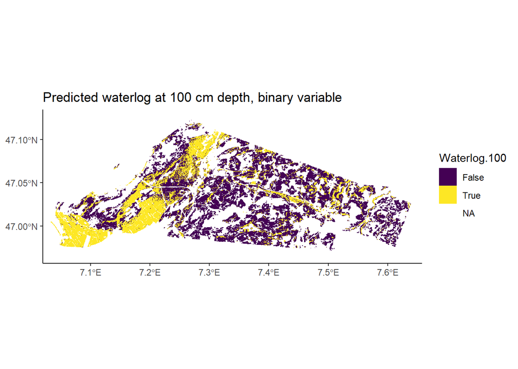

```r
# Let's have a look at our predictions!
# To have some more flexibility, we can plot this in the ggplot-style as such:
raster_pred_bor_plot <- terra::as.factor(raster_pred_bor)
raster_pred_bor_plot_df <- terra::as.data.frame(raster_pred_bor_plot)


ggplot2::ggplot(raster_pred_bor_plot_df) +
  tidyterra::geom_spatraster(data = raster_pred_bor_plot) +
  ggplot2::scale_fill_viridis_d(
    na.value = NA,
    option = "viridis",
    name = "Waterlog.100",
    labels = c("False", "True")
    ) +
  ggplot2::theme_classic() +
  ggplot2::scale_x_continuous(expand = c(0, 0)) +
  ggplot2::scale_y_continuous(expand = c(0, 0)) +
  ggplot2::labs(title = "Predicted waterlog at 100 cm depth, binary variable")
```

```r
terra::writeRaster(
  raster_pred_bor,
  "../data/ra_predicted_bor_ph0-10.tif",
  datatype = "FLT4S",  # FLT4S for floats, INT1U for integers (smaller file)
  filetype = "GTiff",  # GeoTiff format
  overwrite = TRUE     # Overwrite existing file
)
```

# 5.2.3 OBB prediction and model comparison

Repeat the model evaluation and compare the model performance on the test set with what was obtained with the model using all available covariates. Which model generalises better to unseen data?

Would the same model choice be made if we considered the OOB prediction error reported as part of the trained model object?

## Confusion matrix - boruta Forest

```r
# Make classification predictions
y_bor <- as.factor(df_test_bor$waterlog.100)
x_bor <- df_test_bor$pred # Use 0.5 as threshold

# Change class names
levels(y_bor) <- levels(x_bor) <- c("no", "yes")

# plot confusion matrix
conf_matrix_bor <- caret::confusionMatrix(data = x_bor, reference = y_bor)
conf_matrix_bor$table
```

```
##           Reference
## Prediction  no yes
##        no  104  19
##        yes  26  51
```

```r
tp_bor <- conf_matrix_bor$table[2,2]
fp_bor <- conf_matrix_bor$table[2,1]

tn_bor <- conf_matrix_bor$table[1,1]
fn_bor <- conf_matrix_bor$table[1,2]


acc_bor <- na.omit( (tp_bor + tn_bor )/ sum(conf_matrix_bor$table) )
cat("the accuracy for the boruta model is ",acc_bor)
```

```
## the accuracy for the boruta model is  0.775
```

Precision = TP / (TP + FP)

```r
prec_bor <- na.omit(tp_bor / (tp_bor + fp_bor) )
cat("the precision for the boruta model is ", prec_bor)
```

```
## the precision for the boruta model is  0.6623377
```

```r
# f1 <- 2TP / (2TP + FP + FN)
f1_bor <-  na.omit(2*tp_bor / (2*tp_bor + fp_bor +fn_bor) )
 cat("the f1 for the boruta model is ", f1_bor)
```

```
## the f1 for the boruta model is  0.6938776
```

```r
# OOB prediction error of the final model
obb_basic <- sqrt(rf_basic$prediction.error)
obb_bor <- sqrt(rf_bor$prediction.error)
```

```r
cat("Looking at the prediction error, the Boruta Model would be preferred over the
basic case since its Prediction error with", sqrt(rf_bor$prediction.error), "smaller than the one of the basic model"
)
```

```
## Looking at the prediction error, the Boruta Model would be preferred over the
## basic case since its Prediction error with 0.4490578 smaller than the one of the basic model
```

## Comparison table for both models

```r
diag_table <- rbind(diag_basic <- c(round(obb_basic,3), round(acc_basic,3),                                              round(prec_basic,3),round(f1_basic,3) ),
                      diag_bor <-  c(round(obb_bor,3), round(acc_bor,3),                                              round(prec_bor,3),round(f1_bor,3) )
)
diag_table <- as.data.frame(diag_table, row.names = c("Basic RF", "Boruta RF") )
colnames(diag_table) <- c("OBB", "Accuracy", "Precision", "F1")

 better_model <- as.vector(
                 c( rownames(diag_table)[which.min(diag_table$OBB)],
                    rownames(diag_table ) [which.max(diag_table$Accuracy)],
                    rownames(diag_table) [which.max(diag_table$Precision)],
                    rownames(diag_table  )[which.max(diag_table$F1) ]  )  )


 diag_table <- rbind(diag_table, better_model)

rownames(diag_table) <- c("Basic RF", "Boruta RF", "Better Model")
diag_table
```

```
##                    OBB  Accuracy Precision        F1
## Basic RF          0.46      0.76     0.653     0.662
## Boruta RF        0.449     0.775     0.662     0.694
## Better Model Boruta RF Boruta RF Boruta RF Boruta RF
```

In any diagnosis estimate, the boruta Forest performs better over the Basic one, consequently we pfrefer this model over the other.

This goes also for the prediction Error

### Check of the 2 predictions really are different

```r
summary(df_predict$prediction == df_predict_bor$prediction)
```

```
##    Mode   FALSE    TRUE
## logical   24164  563991
```

In AGDS Book Chapter 11, you learned how to optimize hyperparameters using cross-validation.

## 5.3.1 Hyperparameter tuning

Using the training data subset, implement a 5-fold cross-validation to optimise the hyperparameters mtry and min.node.size of the same Random Forest model as implemented above. You may use the {caret} library as demonstrated in AGDS Book.

```r
# The same model formulation is in the previous chapter
pred_plus <- paste(predictors_selected,collapse  = " + ")
pp <- recipes::recipe(as.formula(paste0("waterlog.100 ~", pred_plus)),
                      data = df_train_bor)
```

```r
# Load required libraries
library(caret)
library(ranger)

# Set seed for reproducibility
set.seed(199)

# Define the hyperparameter grid
mtry_values <- seq(20,38,2)
min.node.size_values <- seq(10,30,2)
# Create a data frame to store results
results <- data.frame()

# Perform hyperparameter tuning with 5-fold cross-validation

  # Train the model using caret::train for classification
  mod <- caret::train(
    x = df_train_bor[, predictors_selected],
    y = df_train_bor[, target],
    method = "ranger",
    metric = "Accuracy",
    trControl = trainControl(
      method = "cv",
      number = 5,
      savePredictions = "final"
    ),
    tuneGrid = expand.grid(
      .mtry = mtry_values,
      .min.node.size = min.node.size_values,
      .splitrule = "gini"  # or "extratrees" or "entropy", depending on your preference
    ),
    replace = FALSE,
    sample.fraction = 0.5,
    num.trees = 100,
    seed = 1982
  )
```